# Introduction to Bayesian Statistics with R

5 May 2025

## Average difference?

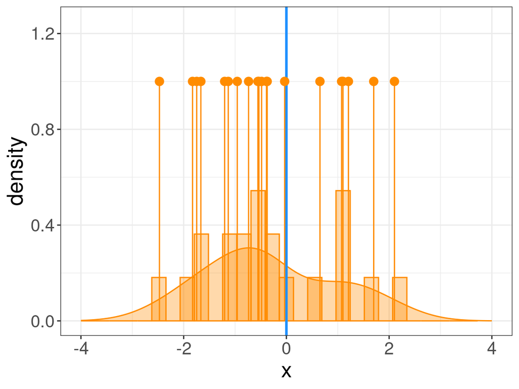

Question: what is the probability of the null hypothesis?

## Bayes theorem again

We would like to know the probability of the hypothesis given the data: \(P(H_0 \mid D)\)

- using Bayes theorem

\[ P(H_0 \mid D) = \frac{P(D \mid H_0)P(H_0)}{P(D)} \] \[P(D) = P(D \mid H_0)P(H_0) + P(D \mid \neg H_0)P(\neg H_0)\]

Need to know:

- the prior probability of the null hypothesis: \(P(H_0)\)
- the likelihood of the data under the null hypothesis: \(P(D \mid H_0)\)
- the likelihood of the data under all other hypotheses: \(P(D \mid \neg H_0)\)

Note we can rescale all likelihoods without changing \(P(H_0 \mid D)\)

\[P(D \mid \ldots) \rightarrow cP(D \mid \ldots)\]

- can ignore constants in the likelihood

## Null likelihood

The null hypothesis:

- true mean is 0
- the data comes from a Gaussian

The probability of each data point \(x_i\) is \(f(x_i)\mathrm{d}x\) with Gaussian probability density

\[f(x) = \frac{1}{\sqrt{2\pi\sigma^2}}\mathrm{e}^{-\frac{(x-0)^2}{2\sigma^2}}\]

The likelihood is then

\[P(D \mid H_0) \propto \prod_{i}f(x_i)\]

ignoring the constants \(\mathrm{d}x\)

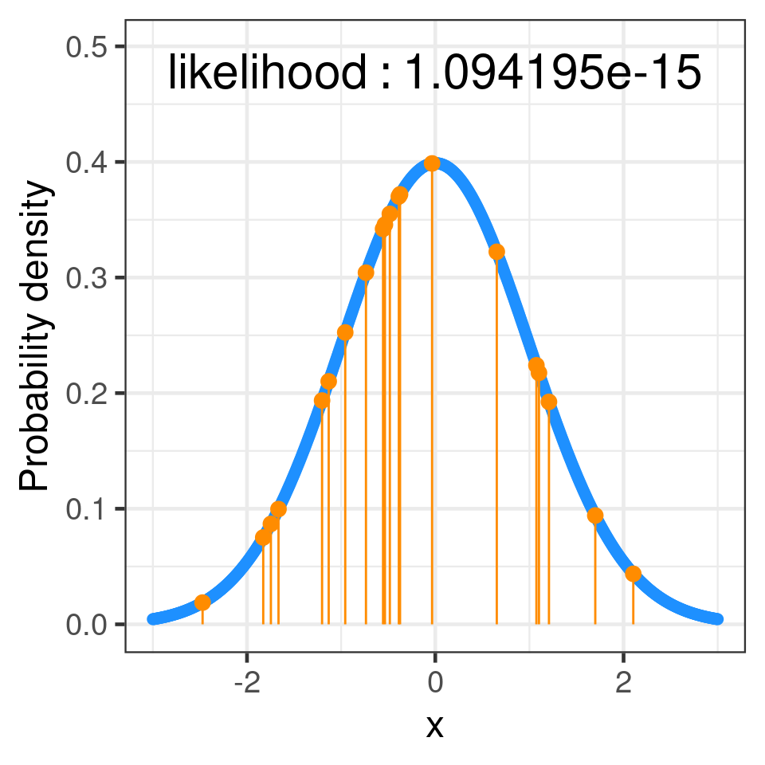

Let’s fix \(\sigma = 1\)

## Null likelihood

The null hypothesis:

- true mean is 0
- the data comes from a Gaussian
- with sd of 1

The likelihood is then

\[P(D \mid H_0) \propto \prod_{i}\mathrm{e}^{-\frac{x_i^2}{2}} = \mathrm{e}^{-\frac{\sum_i x_i^2}{2}}\] further ignoring the constants \(\frac{1}{\sqrt{2\pi}}\)

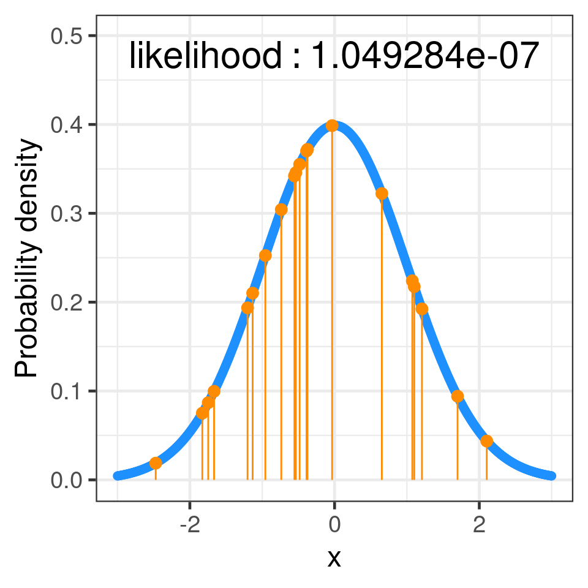

Question: what about under the alternative?

## Alternative likelihood

- true mean is any value \(\mu\)
- the data comes from a Gaussian
- with sd of 1

The likelihood is then

\[P(D \mid \mu, \neg H_0) \propto \prod_{i}\mathrm{e}^{-\frac{(x_i-\mu)^2}{2}} = \mathrm{e}^{-\frac{\sum_i (x_i-\mu)^2}{2}}\]

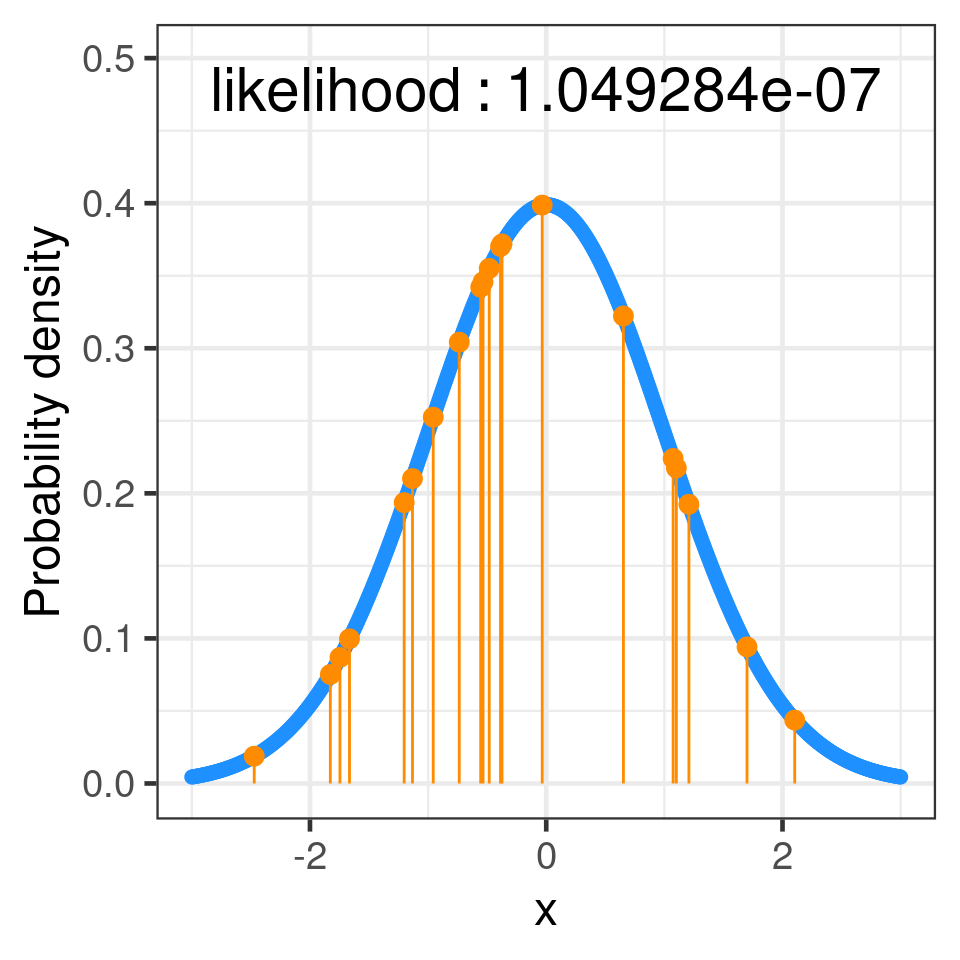

Question: how do we cope with **all** value of \(\mu\)?

## Marginal probability

Answer: Integrate over **all** \(\mu\)!

First we need to define a prior probability (density) for \(\mu\) for our alternative hypothesis

- \(p(\mu \mid \neg H_0)\)

Then we use the probability rule \(P(A \cap B) = P(A \mid B)P(B)\) to write the joint

\[P(D \cap \mu \mid \neg H_0) = P(D \mid \mu, \neg H_0)p(\mu \mid \neg H_0)\]

Finally we marginalise over \(\mu\)

\[P(D \mid \neg H_0) = \int P(D \cap \mu \mid \neg H_0) \mathrm{d} \mu = \int P(D \mid \mu, \neg H_0)p(\mu \mid \neg H_0) \mathrm{d} \mu\]

Question: what should we choose for the prior probability of \(\mu\)?

## Prior choice

Answer: we don’t know which direction we might expect a difference from 0

- symmetric distribution around 0

Or much about the process

- fat tails

So let’s pick a scaled Student-\(t\)

\[\mu \sim s\mathcal{T}_{\nu}\]

- becomes Gaussian as \(\nu\to\infty\)

Question: what values should be pick for the scale \(s\) and the degrees of freedom \(\nu\)?

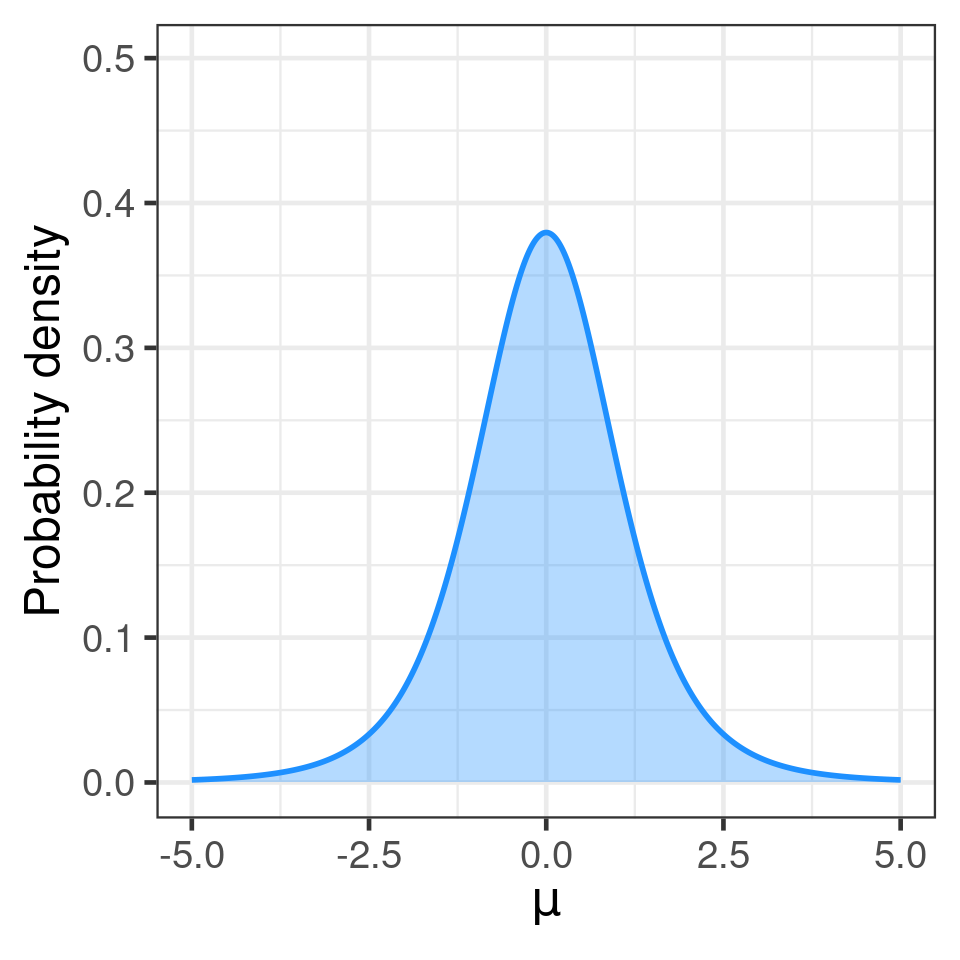

## Alternative likelihood

The alternative likelihood was

\[P(D \mid \mu, \neg H_0) \propto \prod_{i}\mathrm{e}^{-\frac{(x_i-\mu)^2}{2}} = \mathrm{e}^{-\frac{\sum_i (x_i-\mu)^2}{2}}\]

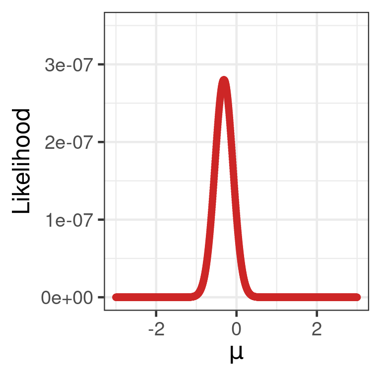

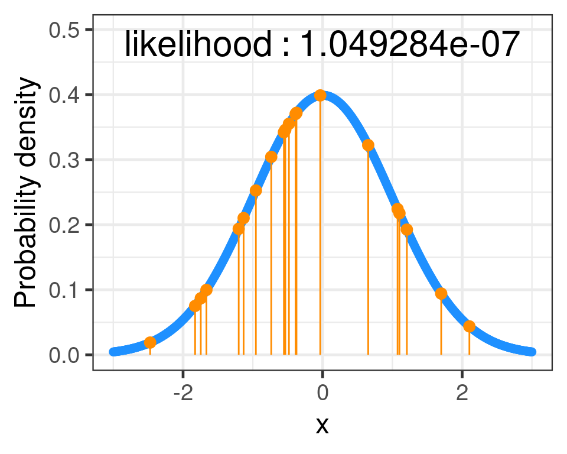

Let’s put it together

## Likelihood and prior

\[P(D \mid \mu, \neg H_0)\]

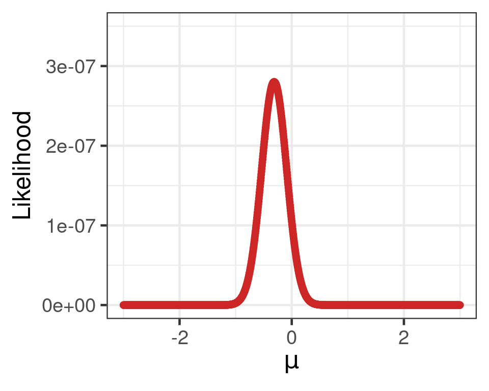

\[p(\mu \mid \neg H_0)\]

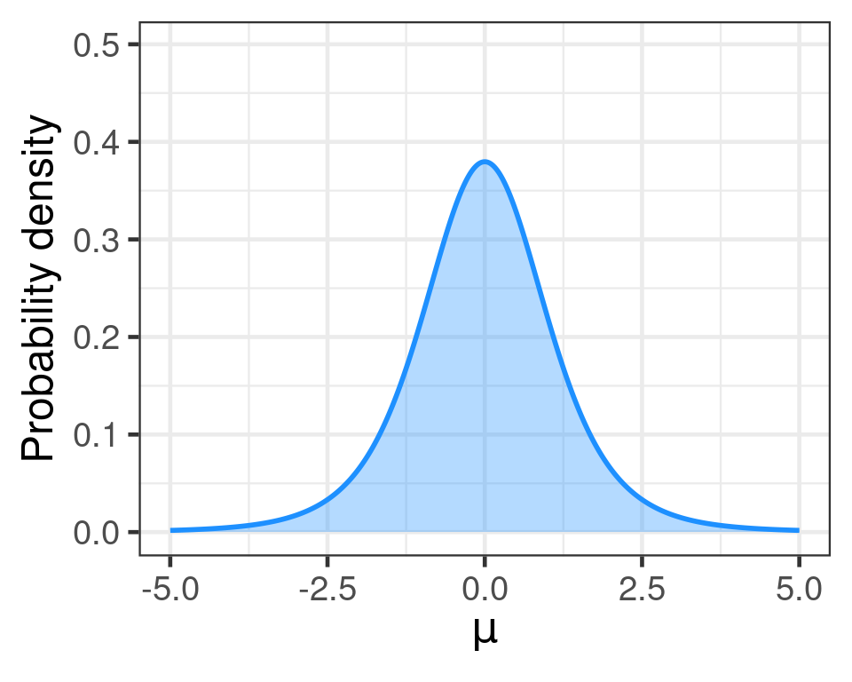

Multiply the two components together

## Joint distribution

\[P(D \cap \mu \mid \neg H_0) = P(D \mid \mu, \neg H_0)p(\mu \mid \neg H_0)\]

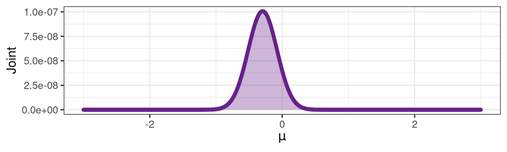

\[P(D \mid \neg H_0) = \int P(D \cap \mu \mid \neg H_0) \mathrm{d} \mu\]

## Probability of the null hypothesis

\[P(H_0 \mid D) = \frac{P(D \mid H_0)P(H_0)}{P(D)} \,, \qquad P(D) = P(D \mid H_0)P(H_0) + P(D \mid \neg H_0)P(\neg H_0)\]

Finally we also need to select a prior probability of the null hypothesis

From numerical integral:

From likelihood at \(\mu = 0\):

- with our likelihood model and prior assumptions

## Posterior

Rather than integrating over \(\mu\)

- the mean \(\mu\) is the quantity we care about!

Rather than trying to find its “true” fixed value

- how would we describe its distribution, given the information we have

\[p(\mu \mid D) \propto P(D \mid \mu) \cdot p(\mu)\]

- the posterior is proportional to the likelihood times the prior
- follows from Bayes theorem

We already have all these quantities

## Posterior

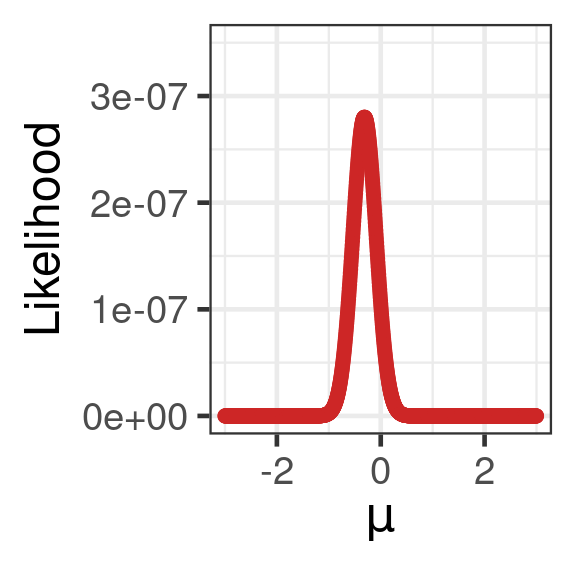

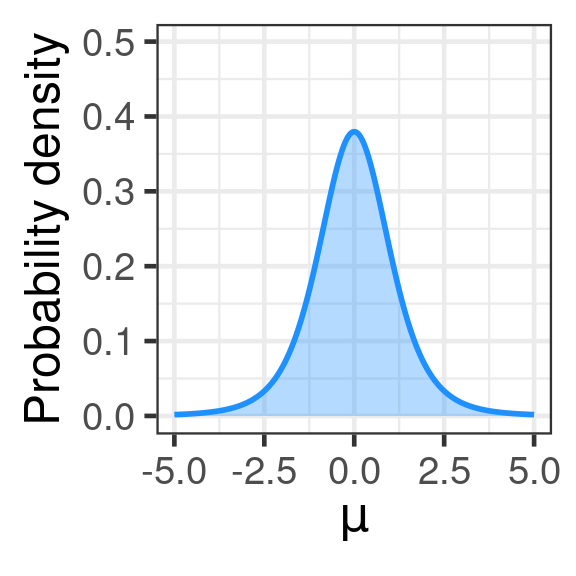

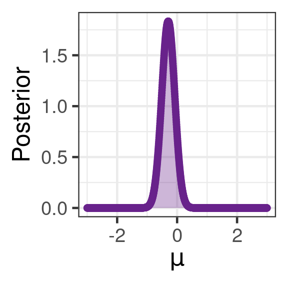

## Credible interval

The credible interval contains the central part of the posterior distribution

- usually 95% is chosen

```
## [1] "[-0.725, 0.125]"
```

Bayesian analogue to the confidence interval

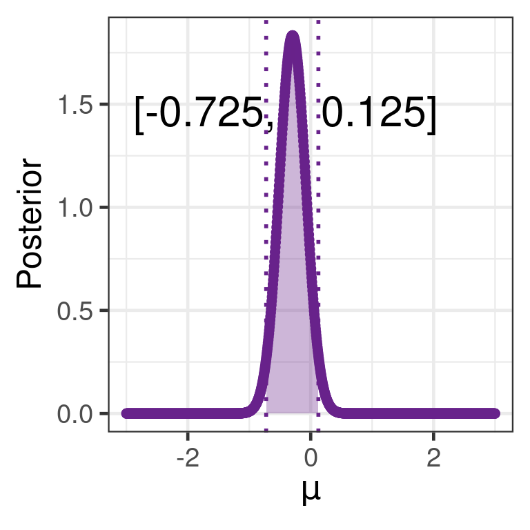

With samples from the posterior

\[\mu_i \qquad i = 1,\ldots,M \, , \qquad \mu_i \sim p(\mu \mid D)\]

- obtain Monte Carlo estimate from sample quantiles

## Summary

The posterior distribution

\[p(\mu \mid D) \propto P(D \mid \mu) \cdot p(\mu)\]

- proportional to the likelihood times the prior
- updates prior belief with the likelihood from the data

Often we cannot compute analytically

- obtain Monte Carlo samples from the posterior
- MCMC, HMC etc

The credible interval contains the central 95% of the posterior

- estimate from samples

Can also use samples to integrate/marginalise

- eg to obtain the estimate of the probability of a hypothesis

\(\rightarrow\) Exercises 4